[OHI British Columbia](http://www.ohibc.org/) | [OHI Science](http://ohi-science.org) | [Citation policy](https://github.com/OHI-Science/ohiprep/releases)

# OHIBC: Alien Species Pressure layers prep

Compiled on Thu Aug 3 11:02:06 2017 by ohara

# 1 Summary

This pressure layer evaluates invasive species pressure on BC regions using the same method as OHI Global and California Current. From Molnar (2008) data, we have data on the number of invasive species (and number of harmful invasives) found within each Marine Ecoregion of the World (MEOW) region. For the global assessment and California Current, score is determined based on the proportion of invasives relative to the global maximum. For OHIBC, we will instead use a species-by-species pressure based on three criteria: *invasive potential*, *ecological impact*, and *management difficulty*. In Molnar 2008, each of these (as well as *scope*) is ranked on a 1 to 4 scale, with 1 being minimal and 4 being intense. Invasive pressure of a species is a geometric mean (rescaled to max = 1) of these threat criteria:

$$pressure_{spp} = P_{spp} = \frac{\prod_{T=1}^N(threat_T)^{1/N}}{4}$$
where T is a threat criterion, N is number of threat criteria scores for that species (excluding NAs).

Scores for each OHIBC region are the area-weighted total species pressure from each ecoregion present. This assumes that invasive species are uniformly distributed throughout the ecoregion.

$$X_{invasive} = \frac{\sum_{ecorgn=1}^{N}((\sum_{spp=1}^M P_{spp}) * A_{ecorgn})}{\sum_{ecorgn=1}^N A_{ecorgn}}$$
where $N$ is the number of ecoregions falling within an OHIBC region; $M$ is the number of species found within that ecoregion; $P_{spp}$ is the pressure score for each species in the ecoregion; and $A_{rgn}$ is the area of the OHIBC region allocated to that ecoregion (so $\sum_{rgn=1}^NA_{ecorgn}$ becomes the total OHIBC region area).

The data has no time scale.

# 2 Data

This layer relies on the same invasive spp database as the global assessment, i.e. Molnar 2008.

- **Reference**: [Molnar et al. (2008)](http://onlinelibrary.wiley.com/doi/10.1890/070064/abstract)
- **Downloaded**: July 31, 2017 from https://www.conservationgateway.org/ConservationPractices/Marine/Pages/marineinvasives.aspx
- **Description**: Number of alien spp per ecoregion, and threat scores for each species based on several invasive threat criteria. Many other dataframes are included in the database; however most are not directly relevant for this assessment.
- **Native data resolution**: Ecoregion
- **Format**: .mdb

# 3 Methods

## 3.1 Determine invasive-potential-weighted species counts in each ecoregion

Cracking open the .mdb MS Access file reveals 32 dataframes in the relational database. Many of these relate to pathways which are not relevant to the scope of this pressure layer. We will use layers that indicate species presence in ecoregions, combined with invasive threat level of each species.

- `A_Occurrences-Marine` represents the occurrences of each species in each ecoregion.
- `A_Threat_scores-Marine` represents the threat scores of each species (regardless of ecoregion). This includes a text description justifying each of the four categories of threat scores for that species.

### 3.1.1 Threat score descriptions

| **Ecological Impact** |
| --- |
| 4 - Disrupts entire ecosystem processes with wider abiotic influences |
| 3 - Disrupts multiple species, some wider ecosystem function, and/or keystone species or species of high conservation value |
| 2 - Disrupts single species with little or no wider ecosystem impact |
| 1 - Little or no disruption (established, but apparently not spreading or spreading with no definitive impact) |
| U - Unknown or not enough information to determine score |
| **Scope** |
| 4 - Multi-ecoregion (Cross-continental/oceanic basin/large river basin) |
| 3 - Ecoregion |
| 2 - Local ecosystem/sub-ecoregion |
| 1 - Has not spread |
| U - Unknown or not enough information to determine score |
| **Invasive Potential** |
| 4 - Currently/recently spreading rapidly (doubling in <10 years) and/or high potential for future rapid spreading |
| 3 - Currently/recently spreading less rapidly and/or potential for future less rapid spreading |
| 2 - Established/present, but not currently spreading and high potential for future spreading |
| 1 - Established/present, but not currently spreading and/or low potential for future spreading |
| U - Unknown or not enough information to determine score |
| **Management Difficulty** |
| 4 - Irreversible and/or can not be contained or controlled |
| 3 - Reversible with difficulty and/or can be controlled with significant ongoing management |
| 2 - Reversible with some difficulty and/or can be controlled with periodic management |
| 1 - Easily reversible, with no ongoing management necessary (eradication) |
| U - Unknown or not enough information to determine score |

### 3.1.2 Calculate mean threat score

Using `A_Threat_scores-Marine` (saved as `_pressures/v2017/int/invspp_threat_raw.csv`), we calculate a weighted threat score for each species using a geometric mean (dropping NAs). This weighted threat score divided by 4 to rescale the highest value to 1.0 - note this means low-threat species still get a minimum score of 0.25.

|  | species_id | species_name | higher_taxa | common_name | threat_txt | pressure |
| --- | --- | --- | --- | --- | --- | --- |
| 1 | 963 | Dasya baillouviana | Algae | Macroalgae, Red algae (Rhodophyta) | ecol_imp = 3; inv_potl = 3; mgt_diff = 4 | 0.825 |
| 2 | 964 | Aglaothamnion halliae | Algae | Red alga, Rhodophyta | ecol_imp = 3; inv_potl = 2; mgt_diff = 4 | 0.721 |
| 3 | 965 | Chattonella aff verruculosa | Algae | (aka Verrucophora fascima) | ecol_imp = 4; inv_potl = 4; mgt_diff = 4 | 1 |
| 4 | 966 | Crepidula onyx | Invertebrate - Mollusc | slipper limpet | ecol_imp = 2; inv_potl = 2; mgt_diff = 4 | 0.63 |
| 5 | 967 | Didemnum vexillum | Ascidian | sea squirt, tunicate | ecol_imp = 4; inv_potl = 2; mgt_diff = 4 | 0.794 |
| 6 | 968 | Ammothea hilgendorfi | Invertebrate - Arthropod - Other | sea spider | ecol_imp = 2; inv_potl = 1; mgt_diff = 2 | 0.397 |
| 7 | 969 | Caulerpa racemosa var. cylindracea | Plant | Sea-grape, green algae | ecol_imp = 3; inv_potl = 4; mgt_diff = 4 | 0.909 |
| 8 | 970 | Siganus rivulatus | Vertebrate - fish | rabbitfish, Marbled spinefoot | ecol_imp = 4; inv_potl = 4; mgt_diff = 4 | 1 |
| 9 | 971 | Brachidontes pharaonis | Invertebrate - Mollusc | Pharaonic mussel | ecol_imp = 3; inv_potl = 3; mgt_diff = 4 | 0.825 |
| 10 | 972 | Cellana rota | Invertebrate - Mollusc | Erythrean limpet, Wheel limpet | ecol_imp = 3; inv_potl = 1; mgt_diff = 4 | 0.572 |

[output cut: 328 more lines]

### 3.1.3 Assign species threat levels to ecoregions

Using `A_Occurrences-Marine`, saved as `int/invspp_occurrences_raw.csv`, join the species threat levels to species occurrences in each ecoregion. Find total threat-weighted sum of species in each ecoregion.

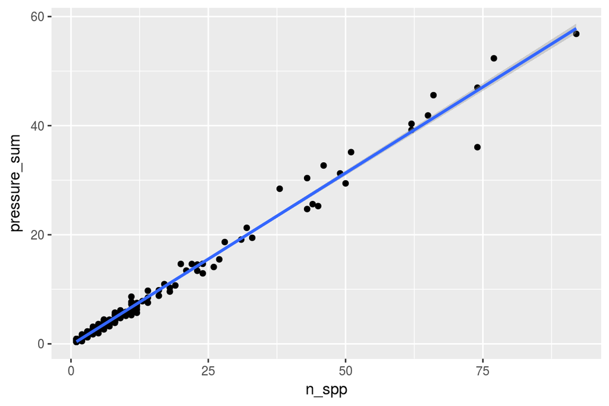

Comparing the pressure-weighted sums to the total species count in each region (which was the metric used in OHI Global 2012-2017 and CC), the linear trend indicates that scores shouldn’t be too greatly affected using this new method.

Linear model: intercept = -0.2267225, slope = 0.6308619, R^2 = 0.9859.

## 3.2 Spatializing invasives to BC regions

Using spatial data for MEOW regions, we can spatialize the invasive species pressures to OHIBC regions.

### 3.2.1 Intersect MEOW with OHIBC

Read in MEOW regions shapefile and intersect with OHIBC regions; calculate area of each OHIBC region that falls within each MEOW region.

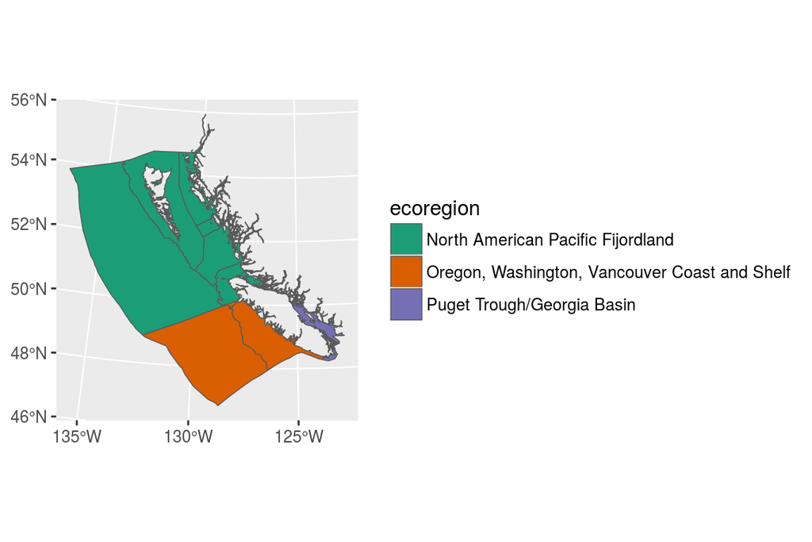

### 3.2.2 Which species are included as invasive in BC?

|  | species_name | common_name | higher_taxa | ecorgns | threat_txt | pressure |
| --- | --- | --- | --- | --- | --- | --- |
| 1 | Myriophyllum spicatum L. | Eurasian Watermilfoil - spiked water-milfoil; myriophylle en épi | Plant | Oregon, Washington, Vancouver Coast and Shelf; Puget Trough/Georgia Basin; North American Pacific Fijordland | ecol_imp = 4; inv_potl = 4; mgt_diff = 4 | 1 |
| 2 | Eriocheir sinensis | Chinese mitten crab, Chinese freshwater edible crab | Invertebrate - Arthropod - Crustacean | Oregon, Washington, Vancouver Coast and Shelf | ecol_imp = 4; inv_potl = 4; mgt_diff = 4 | 1 |
| 3 | Oreochromis mossambicus | aka Sarotherodon mossambicus. Oriental weatherfish, dojo, weather loach, Japanese weatherfish, Amur weatherfish, Mozambiqua tilapia, Mozambique mouthbrooder, Java tilapia, largemouth kurper | Vertebrate - fish | Oregon, Washington, Vancouver Coast and Shelf | ecol_imp = 4; inv_potl = 4; mgt_diff = 4 | 1 |
| 4 | Sargassum muticum | Butblæret sargassotang (Danish), Japanischer Beerentang (German), Japans bessenwier (Dutch), Japansk drivtang, Japweed, sargasse (French), sargasso (Spanish), sargassosnärje (Swedish), strangle weed, … | Algae | Oregon, Washington, Vancouver Coast and Shelf; Puget Trough/Georgia Basin; North American Pacific Fijordland | ecol_imp = 4; inv_potl = 4; mgt_diff = 4 | 1 |
| 5 | Crassostrea gigas | Pacific Oyster, Portuguese oyster, Giant Pacific oyster , Giant oyster , Immigrant oyster , Japanese Oyster , Miyagi oyster , Pacific cupped oyster; FRENCH: Gigas, Huitre géante du Pacifique . SPANISH… | Invertebrate - Mollusc | Oregon, Washington, Vancouver Coast and Shelf; Puget Trough/Georgia Basin; North American Pacific Fijordland | ecol_imp = 3; inv_potl = 4; mgt_diff = 4 | 0.90856029641607 |
| 6 | Spartina alterniflora | Atlantic cordgrass, salt-water cordgrass, saltmarsh cordgrass, smooth cordgrass | Plant | Oregon, Washington, Vancouver Coast and Shelf; Puget Trough/Georgia Basin | ecol_imp = 4; inv_potl = 4; mgt_diff = 3 | 0.90856029641607 |
| 7 | Spartina densiflora | dense-flowered cordgrass, Chilean cordgrass | Plant | Oregon, Washington, Vancouver Coast and Shelf; Puget Trough/Georgia Basin | ecol_imp = 4; inv_potl = 3; mgt_diff = 4 | 0.90856029641607 |
| 8 | Spartina patens | Saltmeadow cordgrass, Saltmeadow Hay, Marsh Grass | Plant | Oregon, Washington, Vancouver Coast and Shelf; Puget Trough/Georgia Basin; North American Pacific Fijordland | ecol_imp = 4; inv_potl = 4; mgt_diff = 3 | 0.90856029641607 |
| 9 | Didemnum cf. lahillei | Didemnum sp. | Ascidian | Oregon, Washington, Vancouver Coast and Shelf; Puget Trough/Georgia Basin | ecol_imp = 4; inv_potl = 3; mgt_diff = 4 | 0.90856029641607 |
| 10 | Mya arenaria | soft-shelled clam, eastern soft-shell clam, long-necked clam, steamer clam, sand gaper | Invertebrate - Mollusc | North American Pacific Fijordland; Puget Trough/Georgia Basin; Oregon, Washington, Vancouver Coast and Shelf | ecol_imp = 4; inv_potl = 3; mgt_diff = 4 | 0.90856029641607 |

[output cut: 68 more lines]

### 3.2.3 Assign invasives pressures to OHIBC rgns

For each ecoregion, calculate the proportional invasive species pressure relative to the global maximum; combine this result with the ecoregion area dataframe. For each OHIBC region, calculate the area-weighted mean of invasive species pressures.

|  | rgn_id | n_spp | pressure |
| --- | --- | --- | --- |
| 1 | 1 | 28 | 0.3285 |
| 2 | 2 | 28 | 0.3285 |
| 3 | 3 | 28 | 0.3285 |
| 4 | 4 | 29.71 | 0.3471 |
| 5 | 5 | 64.91 | 0.7354 |
| 6 | 6 | 61.62 | 0.6859 |
| 7 | 7 | 40.03 | 0.4612 |
| 8 | 8 | 28 | 0.3285 |

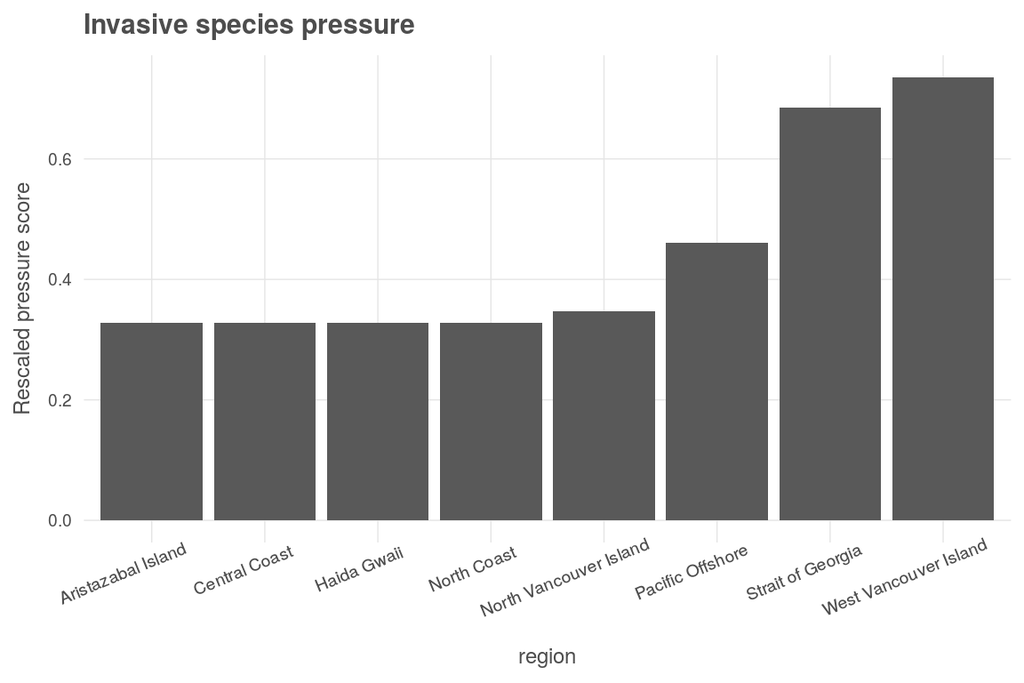

# 4 Provenance

- *Run ID: 10 (c814349); run tag: “standard run”*
- *Run elapsed time: 26.17 seconds; run memory usage: 2011.4 MB*
- *System info:*
  - *System: Linux, Release: 4.4.0-57-generic. Machine: x86_64. User: ohara.*
  - *R version: R version 3.4.1 (2017-06-30), Platform: x86_64-pc-linux-gnu, Running under: Ubuntu 14.04.5 LTS.*
  - *Attached base packages: stats, graphics, grDevices, utils, datasets, methods, base*
  - *Other attached packages: bindrcpp_0.2, provRmd_0.1.1, stringr_1.2.0, RColorBrewer_1.1-2, dplyr_0.7.1, purrr_0.2.2, readr_1.1.0, tidyr_0.6.2, tibble_1.3.3, ggplot2_2.2.1.9000, tidyverse_1.1.1, sf_0.5-1*

[figure not shown]

| sequence | file_name | parent_chunk | file_dir | filetype | uncomm_chgs | commit_hash_short |
| --- | --- | --- | --- | --- | --- | --- |
| 0 | pressures_alien_spp.Rmd | unnamed-chunk-1 | ~/github/ohibc/prep/_pressures/v2017 | parent_script | True | bcc325c |
| 0 | pressures_alien_spp.Rmd#assign_spp_to_ecoregions | assign_spp_to_ecoregions | ~/github/ohibc/prep/_pressures/v2017 | parent_chunk | True | bcc325c |
| 0 | pressures_alien_spp.Rmd#calc_areas_of_meows | calc_areas_of_meows | ~/github/ohibc/prep/_pressures/v2017 | parent_chunk | True | bcc325c |
| 0 | pressures_alien_spp.Rmd#calc_threat | calc_threat | ~/github/ohibc/prep/_pressures/v2017 | parent_chunk | True | bcc325c |
| 0 | pressures_alien_spp.Rmd#determine_BC_invasives | determine_BC_invasives | ~/github/ohibc/prep/_pressures/v2017 | parent_chunk | True | bcc325c |
| 0 | pressures_alien_spp.Rmd#plot_pressures | plot_pressures | ~/github/ohibc/prep/_pressures/v2017 | parent_chunk | True | bcc325c |
| 0 | pressures_alien_spp.Rmd#read_basic_invasives_data | read_basic_invasives_data | ~/github/ohibc/prep/_pressures/v2017 | parent_chunk | True | bcc325c |
| 0 | pressures_alien_spp.Rmd#read_mdb | read_mdb | ~/github/ohibc/prep/_pressures/v2017 | parent_chunk | True | bcc325c |
| 0 | pressures_alien_spp.Rmd#setup | setup | ~/github/ohibc/prep/_pressures/v2017 | parent_chunk | True | bcc325c |
| 0 | pressures_alien_spp.Rmd#unnamed-chunk-1 | unnamed-chunk-1 | ~/github/ohibc/prep/_pressures/v2017 | parent_chunk | True | bcc325c |

[output cut: 24 more lines]